# 使用Hierarchical聚类算法对社会经济数据分类并选择需要援助的国家

## 一、摘要

本文旨在通过Country Socioeconomic Data数据集对世界各国的经济和社会指标进行聚类分析，以便对不同国家之间的相似性和差异性进行分析，然后选择出综合指标结果较差的、需要援助的国家。首先，通过关系热力图、数学特征、缺失值、异常值、重复值等方面对数据集进行观察，然后对数据进行了预处理，使用了PCA方法对数据进行降维，并使用Hopkins统计量来检验数据是否适合聚类分析。接下来，使用层次聚类算法（hierarchical clustering）对数据进行聚类，并通过绘制树形图（dendrogram）来确定最优聚类数量。最后，使用条形图展示了不同聚类簇的指标平均值，以及每个聚类簇包含哪些国家，并根据聚类结果选出了最需要援助的国家。

## 二、Hierarchical聚类算法介绍

- 层次聚类概念：层次聚类(Hierarchical Clustering)是聚类算法的一种，通过计算不同类别数据点间的相似度来创建一棵有层次的嵌套聚类树，距离越小，相似度越高。层次聚类将先计算样本之间的距离，每次将距离最近的点合并到同一个类，然后再计算类与类之间的距离，将距离最近的类合并为一个大类。不停的合并，直到合成了一个类。创建聚类树有自下而上合并和自上而下分裂两种方法，这两种方法分别称为聚合与分裂：
  - 聚合：这是一种 "自下而上 "的方法：每个观测值都从它自己的聚类开始，随着层次结构的上升，成对的聚类被合并起来
  - 分裂：这是一种 "自上而下 "的方法：所有的观测值都从一个聚类开始，随着层次结构的下移而递归地进行分割

  树状图将被用于可视化分组的历史，并找出最佳的集群数量。然后利用生成的树状图，我们确定不与其他任何集群相交的最大垂直距离。然后，在两个极端画一条阈值/水平线。最后，集群的最佳数量等于穿过水平线的垂直线的数量。例如，在下面的案例中，集群数量的最佳选择将是4：

[figure not shown]

- 层次聚类算法实现步骤：聚合型层次聚类的策略是先将每个对象作为一个簇，然后合并这些原子簇为越来越大的簇，直到所有对象都在一个簇中，或者某个终结条件被满足。绝大多数层次聚类属于聚合型层次聚类，它们只是在簇间相似度的定义上有所不同。 这里给出采用最小距离的聚合层次聚类算法流程：
  1. 将每个对象看作一类，计算两两之间的最小距离；
  2. 将距离最小的两个类合并成一个新类；
  3. 重新计算新类与所有类之间的距离；
  4. 重复第二、三步，直到所有类最后合并成一类。

  比如下图中我们有六个数据点{A、B、C、D、E、F}，在最初的步骤中，我们将所有六个数据点视为单独的聚类，第一步是确定哪些元素要合并到一个聚类中。通常情况下，我们要根据选择的距离，取两个最接近的元素。在这个阶段，我们构建一个距离矩阵，其中第i行第j列的数字是第i和第j元素之间的距离。然后，随着聚类的进行，行和列会随着聚类的合并和距离的更新而合并。B,C和D,E是类似的聚类，在第二步中被合并。再次计算新聚类的接近度，并将相似的聚类合并，形成新的聚类A、BC、DEF。集群DEF和BC是相似的，合并在一起形成一个新的集群。现在我们只剩下两个聚类A，BCDEF。最后，所有的聚类被合并在一起，形成一个单一的聚类:

[figure not shown]

## 三、数据集分析与预处理

### 3.1 数据集分析

本次实验采用的数据集是Country Socioeconomic Data，该数据集是一个包含 167 个国家的经济和社会指标的数据集，用于分析不同国家之间的经济和社会发展水平。数据集的来源是世界银行和联合国等机构的统计数据，数据的时间范围是 1960 年至 2015 年。该数据集适用于进行国家间的经济和社会发展水平的比较和分析，也可以用于构建经济和社会发展的预测模型。以下是该数据集的数据字典：

- country：国家名称
- child_mort：每1000名活产婴儿中5岁以下儿童的死亡
- exports：货物和服务出口。以年龄占GDP总量的百分比表示
- health：总卫生支出占GDP总额的百分比
- imports：货物和服务的进口。以年龄占GDP总量的百分比表示
- Income：人均净收入
- Inflation：衡量国内生产总值的年增长率
- life_expec：如果当前的死亡率模式保持不变，一个新生儿的平均寿命
- total_fer：如果当前年龄生育率保持不变，每个妇女将生育的孩子数量
- gdpp：人均GDP。计算方法为GDP总量除以总人口

下面先安装和导入需要使用的库。导入 warnings 模块中的 filterwarnings 函数来抑制警告信息的输出，这可以在开发和调试代码时减少冗余的输出信息; 导入了一些常用的 Python 库，包括 Numpy、Pandas、Matplotlib 和 Seaborn 等，以及 Hierarchical clustering 相关的一些函数；使用 %matplotlib inline 命令来指定 Matplotlib 库的显示模式为 inline 模式，以便在 Jupyter Notebook 中直接显示图形；使用 Pandas 的 set_option 函数来设置数据显示的一些参数，包括最大行数和最大列数，以便在数据显示时进行自定义：

```python
# 抑制警告信息的输出
import warnings
warnings.filterwarnings('ignore')

import numpy as np
import pandas as pd
import matplotlib.pyplot as plt
import seaborn as sns

# 可视化
from matplotlib.pyplot import xticks
%matplotlib inline

# Data display coustomization
pd.set_option('display.max_rows', 50)
pd.set_option('display.max_columns', 50)


from sklearn.preprocessing import StandardScaler

from sklearn.decomposition import PCA
from sklearn.decomposition import IncrementalPCA

from sklearn.cluster import KMeans
# Hierarchical clustering
from scipy.cluster.hierarchy import linkage
from scipy.cluster.hierarchy import dendrogram
from scipy.cluster.hierarchy import cut_tree
from sklearn.neighbors import NearestNeighbors
from random import sample
from numpy.random import uniform
import numpy as np
from math import isnan
```

导入数据集，输出数据集的前10行数据，查看数据集基本情况：

```python
data = pd.DataFrame(pd.read_csv('./input/Country-data.csv'))
data.head(10)
```

|  | country | child_mort | exports | health | imports | income | inflation | life_expec | total_fer | gdpp |
| --- | --- | --- | --- | --- | --- | --- | --- | --- | --- | --- |
| 0 | Afghanistan | 90.2 | 10.0 | 7.58 | 44.9 | 1610 | 9.440 | 56.2 | 5.82 | 553 |
| 1 | Albania | 16.6 | 28.0 | 6.55 | 48.6 | 9930 | 4.490 | 76.3 | 1.65 | 4090 |
| 2 | Algeria | 27.3 | 38.4 | 4.17 | 31.4 | 12900 | 16.100 | 76.5 | 2.89 | 4460 |
| 3 | Angola | 119.0 | 62.3 | 2.85 | 42.9 | 5900 | 22.400 | 60.1 | 6.16 | 3530 |
| 4 | Antigua and Barbuda | 10.3 | 45.5 | 6.03 | 58.9 | 19100 | 1.440 | 76.8 | 2.13 | 12200 |
| 5 | Argentina | 14.5 | 18.9 | 8.10 | 16.0 | 18700 | 20.900 | 75.8 | 2.37 | 10300 |
| 6 | Armenia | 18.1 | 20.8 | 4.40 | 45.3 | 6700 | 7.770 | 73.3 | 1.69 | 3220 |
| 7 | Australia | 4.8 | 19.8 | 8.73 | 20.9 | 41400 | 1.160 | 82.0 | 1.93 | 51900 |
| 8 | Austria | 4.3 | 51.3 | 11.00 | 47.8 | 43200 | 0.873 | 80.5 | 1.44 | 46900 |
| 9 | Azerbaijan | 39.2 | 54.3 | 5.88 | 20.7 | 16000 | 13.800 | 69.1 | 1.92 | 5840 |

输出数据集行数和列数，查看其维度和实例数；查看数据的基本信息，包括每个特征的名称、非空值的数量、数据类型、内存占用等，以用来初步判断数据集中是否存在缺失值和异常值：

```python
print(data.shape)
data.info()
```

```
(167, 10)
<class 'pandas.core.frame.DataFrame'>
RangeIndex: 167 entries, 0 to 166
Data columns (total 10 columns):
 #   Column      Non-Null Count  Dtype
---  ------      --------------  -----
 0   country     167 non-null    object
 1   child_mort  167 non-null    float64
 2   exports     167 non-null    float64
 3   health      167 non-null    float64
 4   imports     167 non-null    float64
 5   income      167 non-null    int64
 6   inflation   167 non-null    float64
 7   life_expec  167 non-null    float64
 8   total_fer   167 non-null    float64
 9   gdpp        167 non-null    int64
dtypes: float64(7), int64(2), object(1)
memory usage: 13.2+ KB
```

分析结果可知：

- 该数据集有167个实例，10个维度
- 该数据集不存在缺失值

使用 Pandas 的 duplicated 函数检查'country'列是否存在重复数据：

```python
sum(data.duplicated(subset = 'country')) == 0
```

```
True
```

分析结果可知：

- 结果为true，说明数据中不存在重复的行，不需要进行去重处理

由于用例数较少，可直接输出各个特征的极值国家，对选择最需要援助的国家提供参考。

使用Seaborn库和Matplotlib库绘制了一个包含9个子图，每个子图显示了一个变量的前10个最低或最高的国家/地区的条形图。指标包括儿童死亡率、生育率、预期寿命、卫生支出、人均GDP、人均收入、通货膨胀率、出口和进口。每个子图都是用条形图表示，横坐标是国家/地区，纵坐标是相应的指标值。这些子图的目的是为了通过视觉方式更好地了解数据集中不同特征的趋势和差异：

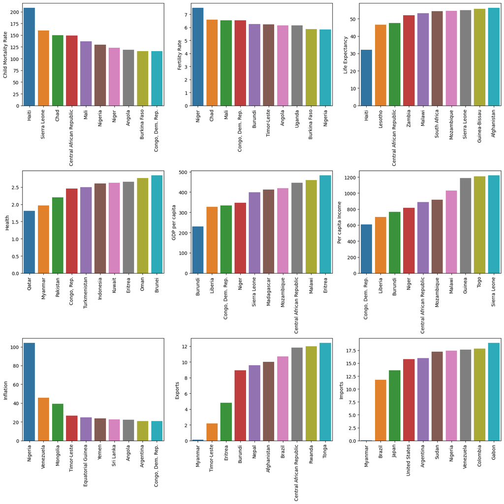

```python
fig, axs = plt.subplots(3,3,figsize = (15,15))

# Child Mortality Rate 最高
top10_child_mort = data[['country','child_mort']].sort_values('child_mort', ascending = False).head(10)
plt1 = sns.barplot(x='country', y='child_mort', data= top10_child_mort, ax = axs[0,0])
plt1.set(xlabel = '', ylabel= 'Child Mortality Rate')

# Fertility Rate 最高
top10_total_fer = data[['country','total_fer']].sort_values('total_fer', ascending = False).head(10)
plt1 = sns.barplot(x='country', y='total_fer', data= top10_total_fer, ax = axs[0,1])
plt1.set(xlabel = '', ylabel= 'Fertility Rate')

# Life Expectancy 最低
bottom10_life_expec = data[['country','life_expec']].sort_values('life_expec', ascending = True).head(10)
plt1 = sns.barplot(x='country', y='life_expec', data= bottom10_life_expec, ax = axs[0,2])
plt1.set(xlabel = '', ylabel= 'Life Expectancy')

# Health 最低
bottom10_health = data[['country','health']].sort_values('health', ascending = True).head(10)
plt1 = sns.barplot(x='country', y='health', data= bottom10_health, ax = axs[1,0])
plt1.set(xlabel = '', ylabel= 'Health')

# The GDP per capita 最低
bottom10_gdpp = data[['country','gdpp']].sort_values('gdpp', ascending = True).head(10)
plt1 = sns.barplot(x='country', y='gdpp', data= bottom10_gdpp, ax = axs[1,1])
plt1.set(xlabel = '', ylabel= 'GDP per capita')

# Per capita Income 最低
bottom10_income = data[['country','income']].sort_values('income', ascending = True).head(10)
plt1 = sns.barplot(x='country', y='income', data= bottom10_income, ax = axs[1,2])
plt1.set(xlabel = '', ylabel= 'Per capita Income')


# Inflation 最高
top10_inflation = data[['country','inflation']].sort_values('inflation', ascending = False).head(10)
plt1 = sns.barplot(x='country', y='inflation', data= top10_inflation, ax = axs[2,0])
plt1.set(xlabel = '', ylabel= 'Inflation')


# Exports 最低
bottom10_exports = data[['country','exports']].sort_values('exports', ascending = True).head(10)
plt1 = sns.barplot(x='country', y='exports', data= bottom10_exports, ax = axs[2,1])
plt1.set(xlabel = '', ylabel= 'Exports')


# Imports 最低
bottom10_imports = data[['country','imports']].sort_values('imports', ascending = True).head(10)
plt1 = sns.barplot(x='country', y='imports', data= bottom10_imports, ax = axs[2,2])
plt1.set(xlabel = '', ylabel= 'Imports')

for ax in fig.axes:
    plt.sca(ax)
    plt.xticks(rotation = 90)

plt.tight_layout()
plt.savefig('eda')
plt.show()
```

分析结果可知：

- 一些国家各项指标都表现不佳，非常需要援助，例如Niger
- 而有些国家则只是在某些指标上表现突出，但其余指标表现良好

  在决定哪些国家需要援助时，我们需要对整个数据集进行综合分析，而非仅仅考虑单一指标

不同的特征之间存在着各种相关性，比如国家Haiti的child_mort（每1000名活产婴儿中5岁以下儿童的死亡）数值最高，也使得该国的life_expec（一个新生儿的平均寿命）数值最低，而通过观察热力图可以判断哪些特征之间存在较强的相关性，从而在后续的分析和建模中考虑是否需要进行特征选择或者特征工程等操作，所以下面对这九个特征使用热力图：

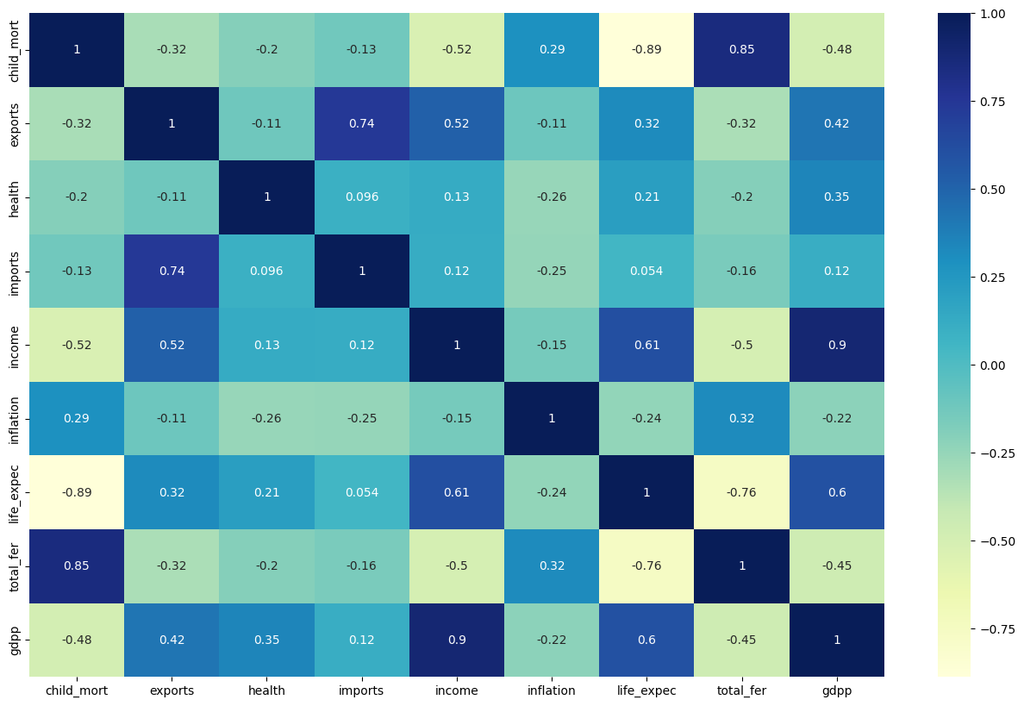

```python
plt.figure(figsize = (16, 10))
sns.heatmap(data.corr(), annot = True, cmap="YlGnBu")
plt.savefig('corrplot')
plt.show()
```

分析结果可知：

- 一些变量之间存在高度正相关，如income和gdpp
- 一些变量之间存在高度负相关，如child_mort和life_expec

  变量间的高度相关性，可能会影响模型的表现，因为这些变量可能会带来重复的信息。所以后面需要使用主成分分析（PCA）来将高度相关的变量转换为新的、线性无关的变量。这将有助于降低变量之间的相关性并提高模型的准确性。

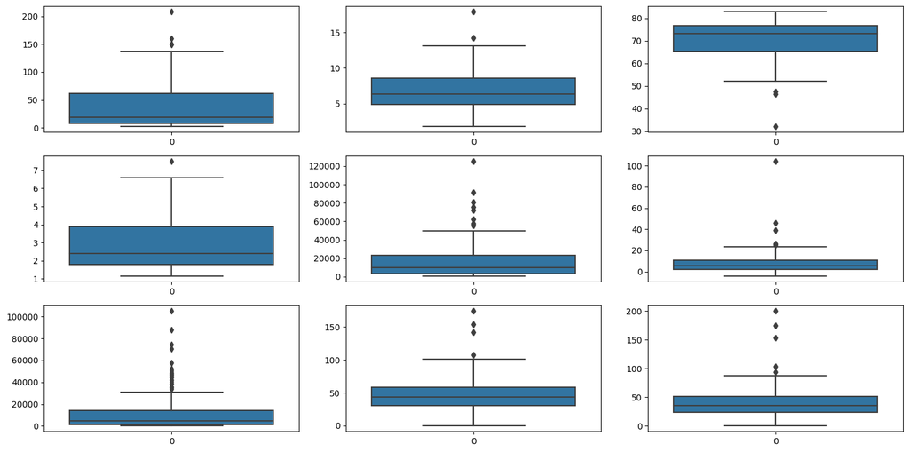

```python
fig, axs = plt.subplots(3,3, figsize = (15,7.5))
plt1 = sns.boxplot(data['child_mort'], ax = axs[0,0])
plt2 = sns.boxplot(data['health'], ax = axs[0,1])
plt3 = sns.boxplot(data['life_expec'], ax = axs[0,2])
plt4 = sns.boxplot(data['total_fer'], ax = axs[1,0])
plt5 = sns.boxplot(data['income'], ax = axs[1,1])
plt6 = sns.boxplot(data['inflation'], ax = axs[1,2])
plt7 = sns.boxplot(data['gdpp'], ax = axs[2,0])
plt8 = sns.boxplot(data['imports'], ax = axs[2,1])
plt9 = sns.boxplot(data['exports'], ax = axs[2,2])


plt.tight_layout()
```

分析结果可知：

- 所有特征都比较集中，但也都存在一些离群值，如收入、gdpp存在较多极大值，说明发达国家经济水平确实远远领先

  离群值是指与其它数据点相比具有异常值的特征值，这些值可能是由于测量误差、数据录入错误或其它原因导致的。离群值可能会严重影响数据的分布和统计分析结果，因此后面需要进行相关处理，以便更好地进行后续分析和建模。

### 3.2 数据预处理及PCA处理

在对数据集进行预处理之前，先保存一份原始数据：

```python
data_help = data.copy()
```

#### 3.2.1 常规预处理

- 处理离群值

  对于每个特征，将数据中小于或大于分位数的数据替换为对应的分位数。具体而言：计算每个变量的上下分位数，得到数据中的第5个和第95个百分位数，然后将小于第5个百分位数的值截断到第5个百分位数，将大于第95个百分位数的值截断到第95个百分位数。这样可以避免数据分析中离群值对结果的影响：

```python
percentiles = data_help['child_mort'].quantile([0.05,0.95]).values
data_help['child_mort'][data_help['child_mort'] <= percentiles[0]] = percentiles[0]
data_help['child_mort'][data_help['child_mort'] >= percentiles[1]] = percentiles[1]

percentiles = data_help['health'].quantile([0.05,0.95]).values
data_help['health'][data_help['health'] <= percentiles[0]] = percentiles[0]
data_help['health'][data_help['health'] >= percentiles[1]] = percentiles[1]

percentiles = data_help['life_expec'].quantile([0.05,0.95]).values
data_help['life_expec'][data_help['life_expec'] <= percentiles[0]] = percentiles[0]
data_help['life_expec'][data_help['life_expec'] >= percentiles[1]] = percentiles[1]

percentiles = data_help['total_fer'].quantile([0.05,0.95]).values
data_help['total_fer'][data_help['total_fer'] <= percentiles[0]] = percentiles[0]
data_help['total_fer'][data_help['total_fer'] >= percentiles[1]] = percentiles[1]

percentiles = data_help['income'].quantile([0.05,0.95]).values
data_help['income'][data_help['income'] <= percentiles[0]] = percentiles[0]
data_help['income'][data_help['income'] >= percentiles[1]] = percentiles[1]

percentiles = data_help['inflation'].quantile([0.05,0.95]).values
data_help['inflation'][data_help['inflation'] <= percentiles[0]] = percentiles[0]
data_help['inflation'][data_help['inflation'] >= percentiles[1]] = percentiles[1]

percentiles = data_help['gdpp'].quantile([0.05,0.95]).values
data_help['gdpp'][data_help['gdpp'] <= percentiles[0]] = percentiles[0]
data_help['gdpp'][data_help['gdpp'] >= percentiles[1]] = percentiles[1]

percentiles = data_help['imports'].quantile([0.05,0.95]).values
data_help['imports'][data_help['imports'] <= percentiles[0]] = percentiles[0]
data_help['imports'][data_help['imports'] >= percentiles[1]] = percentiles[1]

percentiles = data_help['exports'].quantile([0.05,0.95]).values
data_help['exports'][data_help['exports'] <= percentiles[0]] = percentiles[0]
data_help['exports'][data_help['exports'] >= percentiles[1]] = percentiles[1]
```

再次绘制了箱线图，展示经过处理后的数据在各个指标上的分布情况：

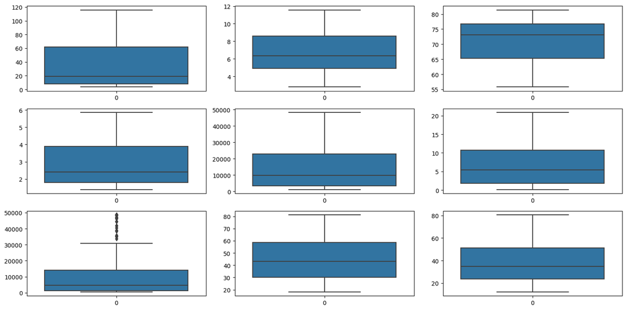

```python
fig, axs = plt.subplots(3,3, figsize = (15,7.5))

plt1 = sns.boxplot(data_help['child_mort'], ax = axs[0,0])
plt2 = sns.boxplot(data_help['health'], ax = axs[0,1])
plt3 = sns.boxplot(data_help['life_expec'], ax = axs[0,2])
plt4 = sns.boxplot(data_help['total_fer'], ax = axs[1,0])
plt5 = sns.boxplot(data_help['income'], ax = axs[1,1])
plt6 = sns.boxplot(data_help['inflation'], ax = axs[1,2])
plt7 = sns.boxplot(data_help['gdpp'], ax = axs[2,0])
plt8 = sns.boxplot(data_help['imports'], ax = axs[2,1])
plt9 = sns.boxplot(data_help['exports'], ax = axs[2,2])

plt.tight_layout()
```

由于数据已经处理了离群值，因此这些箱线图显示的数据应该更加可靠和准确。

- 缩放

  使用scikit-learn中的StandardScaler()函数对数据进行标准化处理，目的是将数据按照均值为0，方差为1进行标准化处理，使得数据分布更加符合正态分布，有利于后续的建模分析：

```python
scaler = StandardScaler()

varlist = ['child_mort', 'exports', 'health', 'imports', 'income', 'inflation', 'life_expec', 'total_fer', 'gdpp']
data_help[varlist] = scaler.fit_transform(data_help[varlist])
```

#### 3.2.2 PCA主成分分析

使用PCA（主成分分析）进行数据降维，将多维数据降为低维数据，以便更方便地进行数据可视化、分类、聚类等操作：

```python
pca = PCA(svd_solver='randomized', random_state=42)
```

将数据中的特征变量赋值给X，将响应变量赋值给y，将X和y传递给PCA算法进行降维和聚类：

```python
X = data_help.drop(['country'],axis=1)
y = data_help['country']
```

进行了主成分分析（PCA）操作，使用了之前创建的PCA对象pca，对X进行拟合训练，即找到X中的主成分方向和对应的方差。PCA可以将原始数据映射到低维空间，这里的低维空间是由主成分方向所组成的线性空间：

```python
pca.fit(X)
```

```
PCA(random_state=42, svd_solver='randomized')
```

在PCA模型上调用components_属性，返回PCA模型的主成分，即变换后的特征向量：

```python
pca.components_
```

```
array([[-0.42162279,  0.23215649,  0.1813805 ,  0.09452367,  0.41088706,
        -0.22517641,  0.43188141, -0.40669251,  0.39376521],
       [-0.032585  , -0.59983764,  0.19168628, -0.72998099,  0.11098633,
         0.07988177,  0.12988256, -0.00878147,  0.18404209],
       [-0.0942617 ,  0.2952823 , -0.6464977 , -0.28358913,  0.19801532,
         0.59047762,  0.11300352, -0.06006172,  0.03591559],
       [ 0.38786406,  0.25262507,  0.28376472,  0.0125846 ,  0.41984315,
         0.16964945, -0.22521603,  0.44660741,  0.49983159],
       [-0.19496651, -0.00132005,  0.57949838,  0.18931826, -0.12407315,
         0.72264373,  0.05963656, -0.13130044, -0.17866759],
       [ 0.0785088 ,  0.54567481,  0.26573873, -0.52564965, -0.06307461,
        -0.15212556, -0.37864464, -0.36368563, -0.21538605],
       [ 0.13002118, -0.35338869, -0.1492239 ,  0.24961913,  0.21838481,
         0.11649633, -0.56635232, -0.59092125,  0.20597879],
       [-0.77090607, -0.02573741, -0.02487332, -0.03452382,  0.09516947,
        -0.05212661, -0.51277027,  0.35827263,  0.01279834],
       [ 0.08044498, -0.10944581,  0.05053595,  0.04428667,  0.72612245,
        -0.06184663,  0.05000336,  0.06636458, -0.6626097 ]])
```

返回的是一个形状为(9,9)的二维数组，其中的每一行对应一个主成分，每一列对应原始数据集的一个特征。这个数组中的值表示每个主成分中每个特征的权重。

下面将PCA后的主成分与原始特征名对应起来，方便后续进行主成分分析结果的可视化或者解释：

```python
colnames = list(X.columns)
pcs_df = pd.DataFrame({'PC1':pca.components_[0],'PC2':pca.components_[1], 'Feature':colnames})
pcs_df.head()
```

|  | PC1 | PC2 | Feature |
| --- | --- | --- | --- |
| 0 | -0.421623 | -0.032585 | child_mort |
| 1 | 0.232156 | -0.599838 | exports |
| 2 | 0.181381 | 0.191686 | health |
| 3 | 0.094524 | -0.729981 | imports |
| 4 | 0.410887 | 0.110986 | income |

使用PCA算法对数据进行降维，并将降维后的主成分可视化：

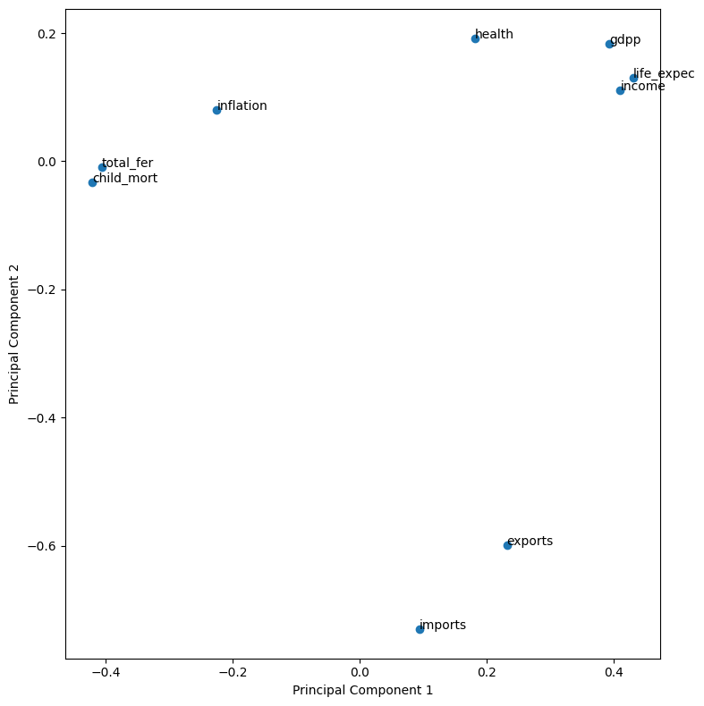

```python
%matplotlib inline
fig = plt.figure(figsize = (8,8))
plt.scatter(pcs_df.PC1, pcs_df.PC2)
plt.xlabel('Principal Component 1')
plt.ylabel('Principal Component 2')
for i, txt in enumerate(pcs_df.Feature):
    plt.annotate(txt, (pcs_df.PC1[i],pcs_df.PC2[i]))
plt.tight_layout()
plt.show()
```

解释每个主成分的方差所占比例：

```python
pca.explained_variance_ratio_
```

```
array([0.49018372, 0.16342209, 0.13895338, 0.09695666, 0.06375024,
       0.01874168, 0.01568208, 0.00866837, 0.00364178])
```

使用了9个主成分，每个主成分的explained variance ratio是一个值，这个值代表该主成分解释了原始数据中的多少方差。

一般希望保留总方差的大部分（通常在70％到90％之间），所以下面使用累计方差贡献率来选择PCA维度：通过绘制累计方差贡献率的图像，可以确定所需的主成分数量，生成一个 scree plot，用于选择 PCA 维度。横轴为 PCA 维度的个数，纵轴为对应维度累计解释方差的百分比：

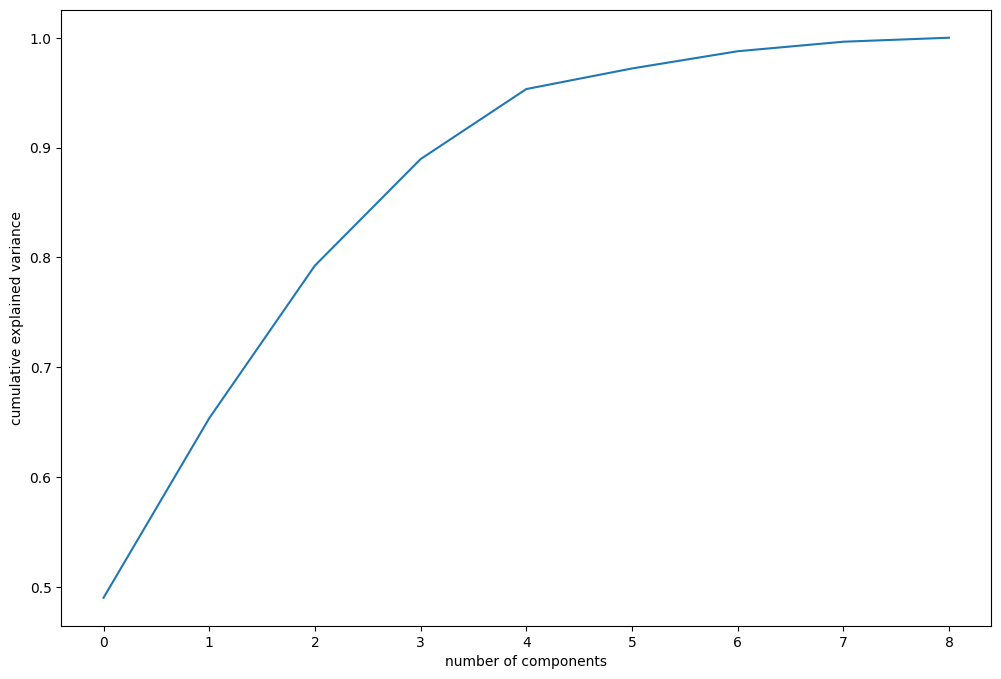

```python
%matplotlib inline
fig = plt.figure(figsize = (12,8))
plt.plot(np.cumsum(pca.explained_variance_ratio_))
plt.xlabel('number of components')
plt.ylabel('cumulative explained variance')
plt.savefig('pca_no')
plt.show()
```

拐点是曲线上的一个转折点，通常表示随着主成分数量的增加，数据集中的可解释方差增加的速度会变得更加缓慢。因此，拐点之前的主成分数量通常被认为是最重要的主成分，可以选择该数量作为主成分的数量。所以观察图像，通过曲线上的拐点来选择主成分的数量，在这个图中，拐点大概在3到4个主成分处。最终决定选择处于拐点处的4作为合适的 PCA 维度，这样可以达到保留足够信息的目的。

下面使用IncrementalPCA进行PCA降维，n_components参数指定了降维后保留的主成分数量为4：

```python
pca_final = IncrementalPCA(n_components=4)
```

使用增量主成分分析进行PCA降维，将数据集X从原来的9个特征降维到4个特征：

```python
df_pca = pca_final.fit_transform(X)
df_pca.shape
```

```
(167, 4)
```

将PCA转换后的特征矩阵转换成DataFrame形式，便于后续处理：

```python
df_pca = pd.DataFrame(df_pca)
df_pca.head()
```

|  | 0 | 1 | 2 | 3 |
| --- | --- | --- | --- | --- |
| 0 | -3.275720 | -0.427284 | -1.055199 | 0.906249 |
| 1 | 0.483960 | -0.161179 | -0.284769 | -1.425874 |
| 2 | -0.447318 | -0.424388 | 1.832563 | -0.622794 |
| 3 | -3.359135 | 1.259644 | 1.980609 | 1.750224 |
| 4 | 1.244074 | 0.697703 | -0.269676 | -0.771221 |

对主成分进行相关性分析，将主成分之间的相关系数计算出来，绘制了一个热力图来展示主成分之间的相关性:

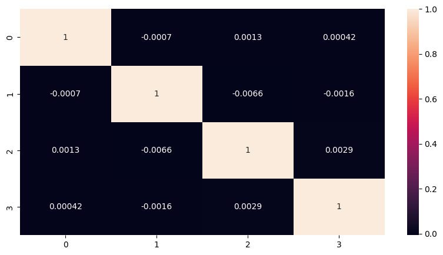

```python
corrmat = np.corrcoef(df_pca.transpose())
%matplotlib inline
plt.figure(figsize = (10,5))
sns.heatmap(corrmat,annot = True)
```

分析结果可知：

- 主成分之间已经不存在多重共线性

  PCA将高维数据集（维度9）转换为低维数据集（维度4），同时保留原始数据的重要信息，从而可以更好地进行聚类分析。同时PCA还去除数据了中的冗余信息和噪音，从而使数据更易于理解和处理。

## 四、Hopkin统计量

Hopkins 统计量用于衡量数据集的聚类倾向性，取值范围为 [0, 1]。当取值接近 1 时，表明数据集有较强的聚类倾向；当取值接近 0.5 时，表明数据集随机分布；当取值接近 0 时，表明数据集是规则分布的，不能进行聚类。下面来具体实现 Hopkins：

1. 计算数据集中每个点到最近的随机点的距离，保存到 ujd 列表中；
2. 计算数据集中每个点到最近的真实点的距离，保存到 wjd 列表中；
3. 计算 Hopkins 统计量 H。

该函数的输入是一个数据集 X，输出是一个 Hopkins 统计量的值：

```python
def hopkins(X):
    d = X.shape[1]
    #d = len(vars) # columns
    n = len(X) # rows
    m = int(0.1 * n)
    nbrs = NearestNeighbors(n_neighbors=1).fit(X.values)

    rand_X = sample(range(0, n, 1), m)

    ujd = []
    wjd = []
    for j in range(0, m):
        u_dist, _ = nbrs.kneighbors(uniform(np.amin(X,axis=0),np.amax(X,axis=0),d).reshape(1, -1), 2, return_distance=True)
        ujd.append(u_dist[0][1])
        w_dist, _ = nbrs.kneighbors(X.iloc[rand_X[j]].values.reshape(1, -1), 2, return_distance=True)
        wjd.append(w_dist[0][1])

    H = sum(ujd) / (sum(ujd) + sum(wjd))
    if isnan(H):
        print(ujd, wjd)
        H = 0

    return H
```

因为之前保存了完整的没有修改的原数据集，下面先对其使用Hopkins统计量：

```python
myX = data.drop(['country'],axis=1)
myX = pd.DataFrame(myX)
hopkins(myX)
```

```
0.9172049112547187
```

对进行了系列预处理后数据集使用Hopkins统计量：

```python
hopkins(df_pca)
```

```
0.701656815188903
```

分析结果可知：

  预处理后数据集的Hopkins统计量降低了，这是因为数据集中的噪声和冗余信息这些对聚类分析没有帮助的信息被移除，Hopkins统计量降低是正常的。如果Hopkins统计量大幅下降，可能需要进一步检查数据集的预处理过程，确保没有移除过多的信息，导致数据集变得过于稀疏。

## 五、Hierarchical聚类算法实现及结果

### 5.1 Hierarchical树状图

对经过预处理的数据进行层次聚类并绘制其树状图，其中使用了最远距离聚类法、欧氏距离：

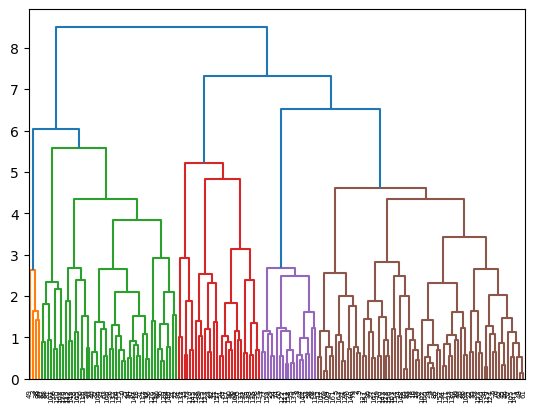

```python
mergings = linkage(df_pca, method = "complete", metric='euclidean')
dendrogram(mergings)
plt.show()
```

分析结构可知：

- 其树状图划分了5个类（5种颜色）

### 5.2 进行Hierarchical聚类

下面使用Hierarchical聚类算法对经过预处理后的数据进行聚类，将聚类结果与原始的PCA结果合并，构成一个新的数据框，新的数据框中增加一列 ClusterID用于标记每个数据点所属的聚类簇：

```python
clusterCut = pd.Series(cut_tree(mergings, n_clusters = 5).reshape(-1,))
df_pca_hc = pd.concat([df_pca, clusterCut], axis=1)
df_pca_hc.columns = ["PC1","PC2","PC3","PC4","ClusterID"]
df_pca_hc.head()
```

|  | PC1 | PC2 | PC3 | PC4 | ClusterID |
| --- | --- | --- | --- | --- | --- |
| 0 | -3.275720 | -0.427284 | -1.055199 | 0.906249 | 0 |
| 1 | 0.483960 | -0.161179 | -0.284769 | -1.425874 | 1 |
| 2 | -0.447318 | -0.424388 | 1.832563 | -0.622794 | 1 |
| 3 | -3.359135 | 1.259644 | 1.980609 | 1.750224 | 2 |
| 4 | 1.244074 | 0.697703 | -0.269676 | -0.771221 | 1 |

将包含国家名称的DataFrame（data_help[['country']]）和PCA聚类后的结果DataFrame（df_pca_hc）合并，便于后续的分析和可视化：

```python
pca_cluster_hc = pd.merge(data_help[['country']], df_pca_hc, left_index=True, right_index=True)
pca_cluster_hc.head()
```

|  | country | PC1 | PC2 | PC3 | PC4 | ClusterID |
| --- | --- | --- | --- | --- | --- | --- |
| 0 | Afghanistan | -3.275720 | -0.427284 | -1.055199 | 0.906249 | 0 |
| 1 | Albania | 0.483960 | -0.161179 | -0.284769 | -1.425874 | 1 |
| 2 | Algeria | -0.447318 | -0.424388 | 1.832563 | -0.622794 | 1 |
| 3 | Angola | -3.359135 | 1.259644 | 1.980609 | 1.750224 | 2 |
| 4 | Antigua and Barbuda | 1.244074 | 0.697703 | -0.269676 | -0.771221 | 1 |

将主成分分析和层次聚类得到的聚类标签与原始数据进行合并，得到每个国家的聚类标签及其它相关数据：

```python
clustered_data_hc = pca_cluster_hc[['country','ClusterID']].merge(data, on = 'country')
clustered_data_hc.head()
```

|  | country | ClusterID | child_mort | exports | health | imports | income | inflation | life_expec | total_fer | gdpp |
| --- | --- | --- | --- | --- | --- | --- | --- | --- | --- | --- | --- |
| 0 | Afghanistan | 0 | 90.2 | 10.0 | 7.58 | 44.9 | 1610 | 9.44 | 56.2 | 5.82 | 553 |
| 1 | Albania | 1 | 16.6 | 28.0 | 6.55 | 48.6 | 9930 | 4.49 | 76.3 | 1.65 | 4090 |
| 2 | Algeria | 1 | 27.3 | 38.4 | 4.17 | 31.4 | 12900 | 16.10 | 76.5 | 2.89 | 4460 |
| 3 | Angola | 2 | 119.0 | 62.3 | 2.85 | 42.9 | 5900 | 22.40 | 60.1 | 6.16 | 3530 |
| 4 | Antigua and Barbuda | 1 | 10.3 | 45.5 | 6.03 | 58.9 | 19100 | 1.44 | 76.8 | 2.13 | 12200 |

### 5.3 结果可视化

对使用Hierarchical聚类算法得到的聚类结果进行分析。其中，对每个聚类簇的 child_mort、exports、health、imports、income、inflation、life_expec、total_fer 和 gdpp 进行了均值计算。这些指标反映了不同国家的经济、健康和人口等方面的情况，通过分析不同聚类簇的均值可以了解这些方面在不同聚类簇中的表现和差异：

```python
hc_clusters_child_mort = 	pd.DataFrame(clustered_data_hc.groupby(["ClusterID"]).child_mort.mean())
hc_clusters_exports = 	pd.DataFrame(clustered_data_hc.groupby(["ClusterID"]).exports.mean())
hc_clusters_health = 	pd.DataFrame(clustered_data_hc.groupby(["ClusterID"]).health.mean())
hc_clusters_imports = 	pd.DataFrame(clustered_data_hc.groupby(["ClusterID"]).imports.mean())
hc_clusters_income = 	pd.DataFrame(clustered_data_hc.groupby(["ClusterID"]).income.mean())
hc_clusters_inflation = 	pd.DataFrame(clustered_data_hc.groupby(["ClusterID"]).inflation.mean())
hc_clusters_life_expec = 	pd.DataFrame(clustered_data_hc.groupby(["ClusterID"]).life_expec.mean())
hc_clusters_total_fer = 	pd.DataFrame(clustered_data_hc.groupby(["ClusterID"]).total_fer.mean())
hc_clusters_gdpp = 	pd.DataFrame(clustered_data_hc.groupby(["ClusterID"]).gdpp.mean())
```

将聚类结果的各项指标均值合并到数据框df中：

```python
df = pd.concat([pd.Series(list(range(0,5))), hc_clusters_child_mort,hc_clusters_exports, hc_clusters_health, hc_clusters_imports,
               hc_clusters_income, hc_clusters_inflation, hc_clusters_life_expec,hc_clusters_total_fer,hc_clusters_gdpp], axis=1)
df.columns = ["ClusterID", "child_mort_mean", "exports_mean", "health_mean", "imports_mean", "income_mean", "inflation_mean",
               "life_expec_mean", "total_fer_mean", "gdpp_mean"]
df
```

|  | ClusterID | child_mort_mean | exports_mean | health_mean | imports_mean | income_mean | inflation_mean | life_expec_mean | total_fer_mean | gdpp_mean |
| --- | --- | --- | --- | --- | --- | --- | --- | --- | --- | --- |
| 0 | 0 | 89.095652 | 25.519783 | 6.843261 | 43.310870 | 3139.413043 | 10.894239 | 59.323913 | 4.897609 | 1536.304348 |
| 1 | 1 | 22.604286 | 35.562700 | 6.167857 | 43.363799 | 10973.571429 | 7.732657 | 72.742857 | 2.268000 | 5903.057143 |
| 2 | 2 | 97.825000 | 70.975000 | 3.550000 | 54.425000 | 12027.500000 | 21.725000 | 62.400000 | 5.325000 | 6142.500000 |
| 3 | 3 | 4.268421 | 32.705263 | 10.448421 | 31.663158 | 38857.894737 | 1.625158 | 80.905263 | 1.812105 | 43505.263158 |
| 4 | 4 | 8.500000 | 82.021429 | 6.391429 | 70.842857 | 41578.214286 | 4.977393 | 77.682143 | 1.876071 | 29641.428571 |

用Python中的seaborn库来绘制聚类后各个簇的不同特征的条形图，共计绘制了9个特征的条形图。其中，第1行的3列分别表示child_mort、exports和health三个特征的条形图；第2行的3列分别表示imports、income和life_expec三个特征的条形图；第3行的3列分别表示inflation、total_fer和gdpp三个特征的条形图：

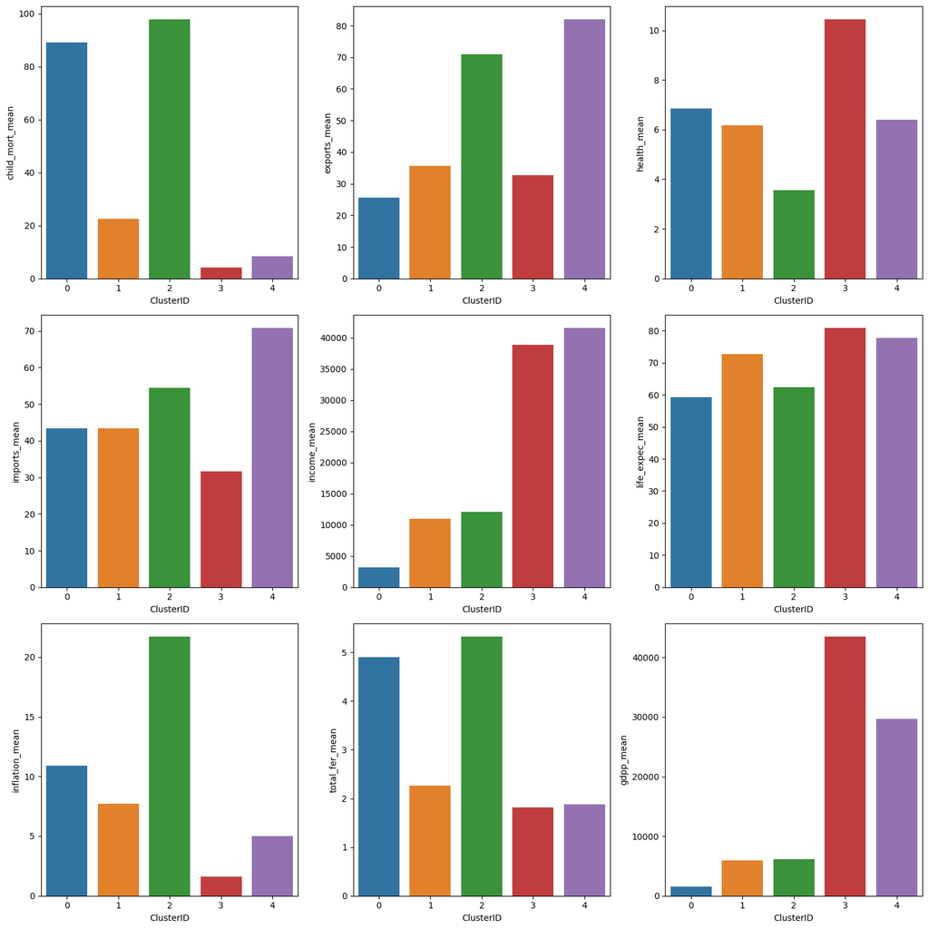

```python
fig, axs = plt.subplots(3,3,figsize = (15,15))

sns.barplot(x=df.ClusterID, y=df.child_mort_mean, ax = axs[0,0])
sns.barplot(x=df.ClusterID, y=df.exports_mean, ax = axs[0,1])
sns.barplot(x=df.ClusterID, y=df.health_mean, ax = axs[0,2])
sns.barplot(x=df.ClusterID, y=df.imports_mean, ax = axs[1,0])
sns.barplot(x=df.ClusterID, y=df.income_mean, ax = axs[1,1])
sns.barplot(x=df.ClusterID, y=df.life_expec_mean, ax = axs[1,2])
sns.barplot(x=df.ClusterID, y=df.inflation_mean, ax = axs[2,0])
sns.barplot(x=df.ClusterID, y=df.total_fer_mean, ax = axs[2,1])
sns.barplot(x=df.ClusterID, y=df.gdpp_mean, ax = axs[2,2])
plt.tight_layout()
```

根据可视化结果以及数据集数据字典的含义，可将国家分为五类：发达国家、发展中国家、欠发达国家、经济转型期国家和贫穷国家，他们具有如下特点：

### 5.4 选择最需要援助的国家

从经过Hierarchical聚类后的数据中提取簇ID为0的国家名称，该类国家属于“低收入、高死亡率”簇，最为需要国际援助：

```python
clustered_data_hc[clustered_data_hc.ClusterID == 0].country.values
```

```
array(['Afghanistan', 'Benin', 'Botswana', 'Burkina Faso', 'Burundi',
       'Cameroon', 'Central African Republic', 'Chad', 'Comoros',
       'Congo, Dem. Rep.', "Cote d'Ivoire", 'Eritrea', 'Gabon', 'Gambia',
       'Ghana', 'Guinea', 'Guinea-Bissau', 'Haiti', 'Iraq', 'Kenya',
       'Kiribati', 'Lao', 'Lesotho', 'Liberia', 'Madagascar', 'Malawi',
       'Mali', 'Micronesia, Fed. Sts.', 'Mozambique', 'Namibia', 'Niger',
       'Nigeria', 'Pakistan', 'Rwanda', 'Senegal', 'Sierra Leone',
       'Solomon Islands', 'South Africa', 'Sudan', 'Tajikistan',
       'Tanzania', 'Timor-Leste', 'Togo', 'Uganda', 'Yemen', 'Zambia'],
      dtype=object)
```

## 六、总结与收获

综上所述，本文介绍了Hierarchical聚类算法在数据集聚类中的应用，并以Country Socioeconomic Data数据集为例，详细讲解了数据预处理、PCA处理、Hopkins统计量、聚类分析等步骤。最终得出了五种国家并选出了最需要援助的国家。在此过程中，我学到了以下知识和技能：

- 学习了Hierarchical聚类算法的基本原理和使用方法
- 了解了使用关系热力图、数学特征、缺失值等方面对数据集进行探索性分析的方法
- 学习了如何使用PCA降维、缩放等方法进行数据预处理，以确保模型的准确性，以及如何将高维数据降维到二维空间中进行可视化
- 学习了如何用Hopkins统计量衡量数据集的聚类倾向性
- 通过对聚类结果的可视化和特征分析，学习了如何根据结果特征进行国家细分，选出了最需要援助的国家，达到了分析数据集的目的